# Florentine Families Network Analysis

A Network Analysis of Florentine Families

Peter Sullivan  
2022-03-22

## Investigate the Network

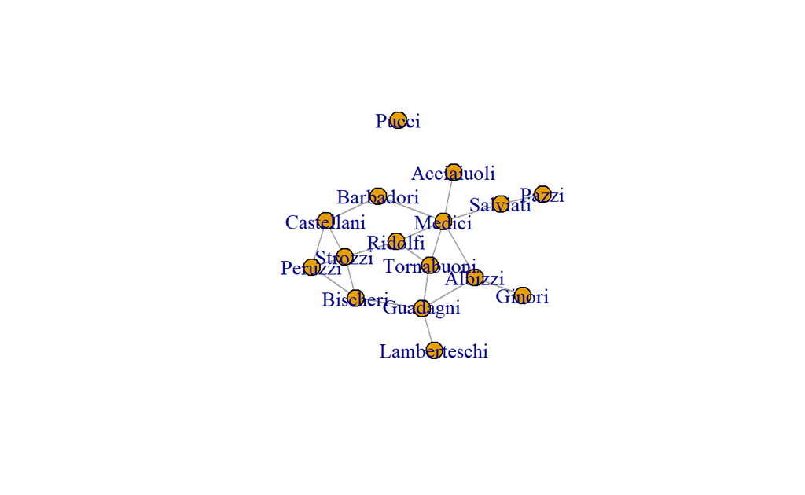

```r
plot(network_igraph)
```

```r
print(network_statnet)
```

```
 Network attributes:
  vertices = 16
  directed = FALSE
  hyper = FALSE
  loops = FALSE
  multiple = FALSE
  bipartite = FALSE
  total edges= 20
    missing edges= 0
    non-missing edges= 20

 Vertex attribute names:
    vertex.names

No edge attributes
```

### Weighted, Directed, and Bipartile?

```r
is_bipartite(network_igraph)
```

```
[1] FALSE
```

```r
is_directed(network_igraph)
```

```
[1] FALSE
```

```r
is_weighted(network_igraph)
```

```
[1] FALSE
```

Looking at Igraph and Statnet, I have confirmed that this is a single mode, undirected, unweighted dataset.

## Dyads, Triads, and Component Structure

### Dyads and Triads

```r
sna::dyad.census(network_statnet)
```

```
     Mut Asym Null
[1,]  20    0  100
```

```r
sna::triad.census(network_statnet)
```

```
     003 012 102 021D 021U 021C 111D 111U 030T 030C 201 120D 120U
[1,] 324   0 195    0    0    0    0    0    0    0  38    0    0
     120C 210 300
[1,]    0   0   3
```

### Transitivity

```r
transitivity(network_igraph, type = "global")
```

```
[1] 0.1914894
```

```r
transitivity(network_igraph, type = "average")
```

```
[1] 0.2181818
```

The average transitivity is slightly higher than the global transitivity. This could be do to certain small clusters with high transitivity.

### Component Structure

```r
igraph::components(network_igraph)$no
```

```
[1] 2
```

```r
igraph::components(network_igraph)$csize
```

```
[1] 15  1
```

It looks like we have one isolate. From the plot above we can tell its the Pucci family.

## Dataframe of Centrality Scores

```r
network::list.vertex.attributes(network_statnet)
```

```
[1] "na"           "vertex.names"
```

```r
network.nodes <- data.frame(name = network_statnet%v%"vertex.names",
                            totdegree = sna::degree(network_statnet),
                            in.degree = sna::degree(network_statnet, cmode = "indegree"),
                            out.degree = sna::degree(network_statnet, cmode = "outdegree"),
                            eigen = round(sna::evcent(network_statnet),3),
                            Bonacich.Power = round(sna::bonpow(network_statnet),3))

rownames(network.nodes)<- NULL
network.nodes %>% arrange(desc(eigen)) %>% head() %>% knitr::kable()
```

| name | totdegree | in.degree | out.degree | eigen | Bonacich.Power |
| --- | --- | --- | --- | --- | --- |
| Medici | 12 | 6 | 6 | 0.430 | -0.569 |
| Strozzi | 8 | 4 | 4 | 0.356 | 0.190 |
| Ridolfi | 6 | 3 | 3 | 0.342 | 1.329 |
| Tornabuoni | 6 | 3 | 3 | 0.326 | 1.139 |
| Guadagni | 8 | 4 | 4 | 0.289 | -0.190 |
| Bischeri | 6 | 3 | 3 | 0.283 | 0.000 |

```r
network.nodes %>% arrange(desc(Bonacich.Power)) %>% head() %>%knitr::kable()
```

| name | totdegree | in.degree | out.degree | eigen | Bonacich.Power |
| --- | --- | --- | --- | --- | --- |
| Ridolfi | 6 | 3 | 3 | 0.342 | 1.329 |
| Tornabuoni | 6 | 3 | 3 | 0.326 | 1.139 |
| Strozzi | 8 | 4 | 4 | 0.356 | 0.190 |
| Bischeri | 6 | 3 | 3 | 0.283 | 0.000 |
| Lamberteschi | 2 | 1 | 1 | 0.089 | 0.000 |
| Pazzi | 2 | 1 | 1 | 0.045 | 0.000 |

The medici’s have the highest eigen centraility while the Ridolfi and Tornauoni’s have the highest Bonacich Power.

### Derived and Reflected Centrality

```r
## Reflected Centrality
mat_flor <- as.matrix(as_adjacency_matrix(network_igraph))
mat_flor.sq <- t(mat_flor) %*% mat_flor

network.nodes$rc <- round(diag(mat_flor.sq)/rowSums(mat_flor.sq),3)

network.nodes$rc <- ifelse(is.nan(network.nodes$rc),0,network.nodes$rc)

network.nodes$eigen.rc <- round(network.nodes$eigen*network.nodes$rc,3)

## Derived Centrality


network.nodes$dc <- round(1 - diag(mat_flor.sq)/rowSums(mat_flor.sq),3)

network.nodes$dc <- ifelse(is.nan(network.nodes$dc),1,network.nodes$dc)

network.nodes$eigen.dc <- round(network.nodes$eigen*network.nodes$dc,3)


network.nodes%>%arrange(desc(eigen.dc)) %>% head() %>% knitr::kable()
```

| name | totdegree | in.degree | out.degree | eigen | Bonacich.Power | rc | eigen.rc | dc | eigen.dc |
| --- | --- | --- | --- | --- | --- | --- | --- | --- | --- |
| Ridolfi | 6 | 3 | 3 | 0.342 | 1.329 | 0.231 | 0.079 | 0.769 | 0.263 |
| Tornabuoni | 6 | 3 | 3 | 0.326 | 1.139 | 0.231 | 0.075 | 0.769 | 0.251 |
| Medici | 12 | 6 | 6 | 0.430 | -0.569 | 0.429 | 0.184 | 0.571 | 0.246 |
| Strozzi | 8 | 4 | 4 | 0.356 | 0.190 | 0.333 | 0.119 | 0.667 | 0.237 |
| Bischeri | 6 | 3 | 3 | 0.283 | 0.000 | 0.273 | 0.077 | 0.727 | 0.206 |
| Peruzzi | 6 | 3 | 3 | 0.276 | -0.569 | 0.300 | 0.083 | 0.700 | 0.193 |

```r
network.nodes%>%arrange(desc(eigen.rc)) %>% head() %>% knitr::kable()
```

| name | totdegree | in.degree | out.degree | eigen | Bonacich.Power | rc | eigen.rc | dc | eigen.dc |
| --- | --- | --- | --- | --- | --- | --- | --- | --- | --- |
| Medici | 12 | 6 | 6 | 0.430 | -0.569 | 0.429 | 0.184 | 0.571 | 0.246 |
| Strozzi | 8 | 4 | 4 | 0.356 | 0.190 | 0.333 | 0.119 | 0.667 | 0.237 |
| Guadagni | 8 | 4 | 4 | 0.289 | -0.190 | 0.400 | 0.116 | 0.600 | 0.173 |
| Castellani | 6 | 3 | 3 | 0.259 | -1.329 | 0.333 | 0.086 | 0.667 | 0.173 |
| Peruzzi | 6 | 3 | 3 | 0.276 | -0.569 | 0.300 | 0.083 | 0.700 | 0.193 |
| Ridolfi | 6 | 3 | 3 | 0.342 | 1.329 | 0.231 | 0.079 | 0.769 | 0.263 |

For derived centrality the highest are the Ridolfi’s, Tournabuoni, and the Medici Family. For reflected centrality the Medici have the most by far at .18. The next highest are from the Strozzi and Guadagni at .11.

## Calculate Closeness Centrality

```r
network.nodes$closeness<-round(sna::closeness(network_statnet, gmode = "graph", cmode = "suminvundir"),3)

network.nodes %>% arrange(desc(closeness)) %>% knitr::kable()
```

| name | totdegree | in.degree | out.degree | eigen | Bonacich.Power | rc | eigen.rc | dc | eigen.dc | closeness |
| --- | --- | --- | --- | --- | --- | --- | --- | --- | --- | --- |
| Medici | 12 | 6 | 6 | 0.430 | -0.569 | 0.429 | 0.184 | 0.571 | 0.246 | 0.633 |
| Guadagni | 8 | 4 | 4 | 0.289 | -0.190 | 0.400 | 0.116 | 0.600 | 0.173 | 0.539 |
| Ridolfi | 6 | 3 | 3 | 0.342 | 1.329 | 0.231 | 0.079 | 0.769 | 0.263 | 0.533 |
| Albizzi | 6 | 3 | 3 | 0.244 | -2.088 | 0.273 | 0.067 | 0.727 | 0.177 | 0.522 |
| Strozzi | 8 | 4 | 4 | 0.356 | 0.190 | 0.333 | 0.119 | 0.667 | 0.237 | 0.522 |
| Tornabuoni | 6 | 3 | 3 | 0.326 | 1.139 | 0.231 | 0.075 | 0.769 | 0.251 | 0.522 |
| Bischeri | 6 | 3 | 3 | 0.283 | 0.000 | 0.273 | 0.077 | 0.727 | 0.206 | 0.480 |
| Barbadori | 4 | 2 | 2 | 0.212 | -1.519 | 0.222 | 0.047 | 0.778 | 0.165 | 0.472 |
| Castellani | 6 | 3 | 3 | 0.259 | -1.329 | 0.333 | 0.086 | 0.667 | 0.173 | 0.461 |
| Peruzzi | 6 | 3 | 3 | 0.276 | -0.569 | 0.300 | 0.083 | 0.700 | 0.193 | 0.452 |
| Salviati | 4 | 2 | 2 | 0.146 | -0.190 | 0.286 | 0.042 | 0.714 | 0.104 | 0.439 |
| Acciaiuoli | 2 | 1 | 1 | 0.132 | -0.380 | 0.167 | 0.022 | 0.833 | 0.110 | 0.394 |
| Lamberteschi | 2 | 1 | 1 | 0.089 | 0.000 | 0.250 | 0.022 | 0.750 | 0.067 | 0.358 |
| Ginori | 2 | 1 | 1 | 0.075 | -1.898 | 0.333 | 0.025 | 0.667 | 0.050 | 0.356 |
| Pazzi | 2 | 1 | 1 | 0.045 | 0.000 | 0.500 | 0.022 | 0.500 | 0.022 | 0.318 |
| Pucci | 0 | 0 | 0 | 0.000 | 0.000 | 0.000 | 0.000 | 1.000 | 0.000 | 0.000 |

```r
summary(network.nodes$closeness)
```

```
   Min. 1st Qu.  Median    Mean 3rd Qu.    Max.
 0.0000  0.3850  0.4665  0.4376  0.5220  0.6330
```

The medici family has the highest closeness centrality of .633. The median closeness is .467 and the mean is.437, so the max of .633 is not to much higher then everyone else in the group.

## Closeness Centralization

```r
centr_clo(network_igraph)$centralization
```

```
[1] 0.1790292
```

I’m a bit confused why the closeness centraliztion is so much lower then average closeness seen above.

## Betweenness Centrality

```r
#igraph::betweenness(network_igraph, directed = FALSE)
network.nodes$betweenness <-round(sna::betweenness(network_statnet, gmode = "graph"),3)
network.nodes %>% arrange(desc(betweenness)) %>% head() %>% knitr::kable()
```

| name | totdegree | in.degree | out.degree | eigen | Bonacich.Power | rc | eigen.rc | dc | eigen.dc | closeness | betweenness |
| --- | --- | --- | --- | --- | --- | --- | --- | --- | --- | --- | --- |
| Medici | 12 | 6 | 6 | 0.430 | -0.569 | 0.429 | 0.184 | 0.571 | 0.246 | 0.633 | 47.500 |
| Guadagni | 8 | 4 | 4 | 0.289 | -0.190 | 0.400 | 0.116 | 0.600 | 0.173 | 0.539 | 23.167 |
| Albizzi | 6 | 3 | 3 | 0.244 | -2.088 | 0.273 | 0.067 | 0.727 | 0.177 | 0.522 | 19.333 |
| Salviati | 4 | 2 | 2 | 0.146 | -0.190 | 0.286 | 0.042 | 0.714 | 0.104 | 0.439 | 13.000 |
| Ridolfi | 6 | 3 | 3 | 0.342 | 1.329 | 0.231 | 0.079 | 0.769 | 0.263 | 0.533 | 10.333 |
| Bischeri | 6 | 3 | 3 | 0.283 | 0.000 | 0.273 | 0.077 | 0.727 | 0.206 | 0.480 | 9.500 |

```r
centr_betw(network_igraph, directed = F)$centralization
```

```
[1] 0.3834921
```

## Network Constraint

```r
network.nodes$Constraint <- round(constraint(network_igraph),3)

network.nodes %>% arrange(desc(Constraint)) %>% head()%>% knitr::kable()
```

| name | totdegree | in.degree | out.degree | eigen | Bonacich.Power | rc | eigen.rc | dc | eigen.dc | closeness | betweenness | Constraint |
| --- | --- | --- | --- | --- | --- | --- | --- | --- | --- | --- | --- | --- |
| Acciaiuoli | 2 | 1 | 1 | 0.132 | -0.380 | 0.167 | 0.022 | 0.833 | 0.110 | 0.394 | 0.0 | 1.000 |
| Ginori | 2 | 1 | 1 | 0.075 | -1.898 | 0.333 | 0.025 | 0.667 | 0.050 | 0.356 | 0.0 | 1.000 |
| Lamberteschi | 2 | 1 | 1 | 0.089 | 0.000 | 0.250 | 0.022 | 0.750 | 0.067 | 0.358 | 0.0 | 1.000 |
| Pazzi | 2 | 1 | 1 | 0.045 | 0.000 | 0.500 | 0.022 | 0.500 | 0.022 | 0.318 | 0.0 | 1.000 |
| Peruzzi | 6 | 3 | 3 | 0.276 | -0.569 | 0.300 | 0.083 | 0.700 | 0.193 | 0.452 | 2.0 | 0.656 |
| Barbadori | 4 | 2 | 2 | 0.212 | -1.519 | 0.222 | 0.047 | 0.778 | 0.165 | 0.472 | 8.5 | 0.500 |

```r
network.nodes %>% arrange(Constraint) %>% head()%>%knitr::kable()
```

| name | totdegree | in.degree | out.degree | eigen | Bonacich.Power | rc | eigen.rc | dc | eigen.dc | closeness | betweenness | Constraint |
| --- | --- | --- | --- | --- | --- | --- | --- | --- | --- | --- | --- | --- |
| Medici | 12 | 6 | 6 | 0.430 | -0.569 | 0.429 | 0.184 | 0.571 | 0.246 | 0.633 | 47.500 | 0.210 |
| Guadagni | 8 | 4 | 4 | 0.289 | -0.190 | 0.400 | 0.116 | 0.600 | 0.173 | 0.539 | 23.167 | 0.250 |
| Albizzi | 6 | 3 | 3 | 0.244 | -2.088 | 0.273 | 0.067 | 0.727 | 0.177 | 0.522 | 19.333 | 0.333 |
| Strozzi | 8 | 4 | 4 | 0.356 | 0.190 | 0.333 | 0.119 | 0.667 | 0.237 | 0.522 | 9.333 | 0.458 |
| Ridolfi | 6 | 3 | 3 | 0.342 | 1.329 | 0.231 | 0.079 | 0.769 | 0.263 | 0.533 | 10.333 | 0.460 |
| Tornabuoni | 6 | 3 | 3 | 0.326 | 1.139 | 0.231 | 0.075 | 0.769 | 0.251 | 0.522 | 8.333 | 0.460 |

As expected the Medici Family has the lowest amount of constraint.

## Gould-Fernandez Brokerage

We have an undirected network, therefor we are unable to calculate the gould-fernandez brokerage.